# lab

**Convex and Distributed Optimization Lab**  
**MSIAM — Université Grenoble Alpes — 2019/2020**  
**Lecturers: Jérôme Malick, Yassine Laguel, Sélim Chraibi**

**Author(s): Yassine FAKIHANI, Nils DEFAUW, Nathan RAYNAL-CASTANG**

```python
# Automatic reload of local libraries
%load_ext autoreload
%autoreload 2
%reload_ext autoreload
%matplotlib inline
```

```
The autoreload extension is already loaded. To reload it, use:
  %reload_ext autoreload
```

> **I. Introduction**  
> **II. The optimization problem**  
> **III. Implementing the solvers**  
> GD (Gradient descent))  
> SGD (Stochastic Gradient Descent))  
> SAGA (Stochastic Average Gradient "Amélioré"))  
> SVRG (Stochastic Variance Reduced Gradient))  
> Comparison  
> **IV. Regularization**  
> **V. Further development**

In this lab, you will implement optimization algorithms that you've studied in class and use them to fit a logistic regression classification model.

You will be implementing a simplified version of [`sklearn.linear_model.LogisticRegression`](https://scikit-learn.org/stable/modules/generated/sklearn.linear_model.LogisticRegression.html).

Part of the work has already been done for you (see the `\lib` folder), so you'll only have to implement the `##### TODO (i) #####` sections of the code. Whenever you complete such a section, we ask you to **copy it in this notebook**. We want you to **only send us a pdf or html export of this notebook** so we won't be able to see your work if it's not in this notebook.

Report in groups of 1 to 3 students.  
**Due date:** Monday, January 6, 2019 (before midnight).  
**Send to:** cdo.grenoble@gmail.com

# I. Introduction

We consider the [Student Performance](http://archive.ics.uci.edu/ml/datasets/Student+Performance) dataset. This dataset contains student demographic, social, school-related features, how many classes they've missed, etc.

The goal we give ourselves is to predict whether a student will pass (final grade > 12).

We denote $A \in \mathcal{M}_{n,d}(\mathbb{R})$ the feature matrix, containing $n$ samples with $d$ features, and $b \in \{-1,1\}^n$ the label vector where $-1$ encodes `fail` and $1$ encodes `pass`.

The data has already been preprocessed (yay less work for you 🎉). You can check `\lib\datasets.py` if you're curious, otherwise, you can just use the following to load your dataset:

```python
from lib.datasets import load_student_data

A_train, A_test, b_train, b_test = load_student_data('data/student-mat.csv', split=0.25)
```

As mentioned previously, you're going to implement a simplified version of [`sklearn.linear_model.LogisticRegression`](https://scikit-learn.org/stable/modules/generated/sklearn.linear_model.LogisticRegression.html). So let's first see what the finished product should look like.

**Question:**

- Import [sklearn.linear_model.LogisticRegression](https://scikit-learn.org/stable/modules/generated/sklearn.linear_model.LogisticRegression.html) .
- Create an instance of sklearn's logistic regression classifiers with SAGA as its solver.
- Fit the classifier on the training data and compute the score of the fitted model on the test set.

```python
from sklearn.linear_model import LogisticRegression
import numpy as np

classifier = LogisticRegression(solver = 'saga', max_iter = 500)
classifier.fit(A_train, b_train)

classifier.score(A_test, b_test)
```

```
0.898989898989899
```

# II. The optimization problem

Logistic regression consists in finding the parameter $x \in \mathbb{R}^d$ that best fits: $$ b_i = \begin{cases} \phantom{-}1 \ \textrm{ if }\ \langle a_{i}, x\rangle \ge 0 \\ -1 \ \textrm{ if }\ \langle a_{i}, x\rangle < 0 \end{cases} $$ for all the samples $i$ of the training set (where $a_i$ is the $i^{th}$ line of $A$ and $b_i$ the $i^{th}$ element of $b$). To measure this fit, logistic regression chooses the following loss:

$$ \textrm{LogisticLoss}(b_i, \left\langle a_{i}, x\right\rangle ) = \log \left(1+\exp \left(-b_{i}\left\langle a_{i}, x\right\rangle\right)\right) $$

The corresponding optimization problem we will consider is the following:

Minimization of the empirical risk $f$ of the $L_2$-regularized logistic regression model, on the dataset $(A_{\textrm{train}},b_{\textrm{train}})$: $$ \begin{aligned} \textrm{min}_{x\in \mathbb{R}^d} \ f(x) \ &= \ \textrm{min}_{x\in \mathbb{R}^d} \ \frac{1}{n_{\textrm{train}}} \sum_{i=1}^{n_{\textrm{train}}} f_i(x) \\ &= \ \textrm{min}_{x\in \mathbb{R}^d}\frac{1}{n_{\textrm{train}}} \sum_{i=1}^{n_{\textrm{train}}} \textrm{LogisticLoss}(b_i, \left\langle a_{i}, x\right\rangle ) + \frac{l_2}{2}\|x\|^{2}_2, \end{aligned} $$ where $l_2 \ge 0$ is the $L_2$ regularization coefficient.

To simplify the notation, we'll stop indexing $A$, $b$ and $n$ with "$\textrm{train}$" in the following.

**Question:** $f$ is $\mu$-strongly convex.

- Give a lower bound on $\mu$.
- Complete **TODO (1)** in **\lib\linear_model.py**.

> **Answer:**

The Logistic Loss is a composition of $x \longmapsto \log(1 + \exp{(-x)})$ and $x \longmapsto - b_i \langle a_{i}, x \rangle $. Both of these function are convex and we know that the composition of two convex functions is a convex function. So the Logistic Loss is a convex function. So it is also $0$-strongly convex, because $\textrm{LogisticLoss}(b_i, \left\langle a_{i}, x\right\rangle ) - \frac{0}{2}\|x\|^{2} $ is convex.

Furthermore, the mapping $I(x) = \frac{l_2}{2}\|x\|^{2}$ is $l_2$ strongly convex. Proof:

For $x \in R^d$ we have: $\frac{\partial I(x)}{\partial x_1} = \frac{\partial}{\partial x_1} (\frac{l_2}{2} \sum_{i=1}^d x_i ^2) = l_2 x_1 \Longrightarrow \nabla I(x) = l_2 x$.

And $I$ is $l_2$-strongly convex iff $\forall x, y \in R^d$: $$I(x) - I(y) \leq - \frac{l_2}{2} \|x - y \|^{2} + \langle l_2 x, x-y \rangle $$

$$\ \Longleftrightarrow \frac{l_2}{2} \|x\|^{2} - \frac{l_2}{2} \|y\|^{2} \leq l_2 \|x\|^{2}- l_2 \langle x, y \rangle - \frac{l_2}{2} \|x - y \|^{2} $$

$$\Longleftrightarrow \|x - y \|^{2} \leq \|x\|^{2} + \|y\|^{2} - 2 \langle x, y \rangle $$

The last equality is true. So i conclude that: $I$ is $l_2$-strongly convex.

Also, we know that if $h_1$ if $\mu_1$-strongly convex and $h_2$ is $\mu_2$-strongly convex then $(h_1 + h_2)$ is $\sigma$-strongly convex with $\sigma \geq \mu_1 + \mu_2$.

So we conclude that the function $f$ is $\mu$-strongly convex, with $\mu \geq l_2$.

So a lower bound on $\mu$ is $l_2$.

**Question:** For any square matrix $M$, denote $\lambda_{\max}(M)$ the largest eighenvalue of $M$.

- Prove that $\lambda_{\max}(\nabla^2 f_i) \le \lambda_{\max}(\frac{a_i a_i^T}{4} + l_2 I_d)$
- Prove that $\lambda_{\max}(a_i a_i^T) \le \|a_i\|^2_2$

> **Answer:**

We know that: $\lambda_{max}(V) = \sup_{x \in R^d s.t. \|x\| = 1}(x^T V x)$. We are going to use this property to prove the above inequalities.

- Let m be fixe, and $x \in R^d$, we have: $f_m (x) = \textrm{LogisticLoss}(-b_m \left\langle a_{m}, x\right\rangle ) + \frac{l_2}{2}\|x\|^{2} = \log (1+ \exp (-b_m \left\langle a_{m}, x\right\rangle )) + \frac{l_2}{2} \|x\|^2$

We know that: $\frac{\partial f_m}{\partial x_j} = \frac{- b \exp (-b_m \langle a_{m}, x \rangle )}{(1+ \exp (-b_m \left\langle a_{m}, x\right\rangle ))}$

And for $i \neq j$, we have: $$\frac{\partial^2 f_m (x)}{\partial x_i x_j} = \frac{b^2 a_i a_j \exp (-b_m \langle a_{m}, x \rangle ) + b^2 a_i a_j \exp (-b_m \langle a_{m}, x \rangle ) - b^2 a_i a_j \exp (-b_m \langle a_{m}, x \rangle )}{(1+ \exp (-b_m \langle a_{m}, x \rangle ))^2}$$

So: $$\boxed{\frac{\partial^2 f_m (x)}{\partial x_i x_j} = \frac{a_i a_j \exp (-b_m \langle a_{m}, x \rangle )}{(1+ \exp (-b_m \langle a_{m}, x \rangle ))^2}} $$

In another hand, when $i=j$, we get:

$$\boxed{\frac{\partial^2 f_m (x)}{\partial x_j^2} = \frac{a_j^2 \exp (-b_m \langle a_{m}, x \rangle )}{(1+ \exp (-b_m \langle a_{m}, x \rangle ))^2} + l_2} $$

We conclude that: $$\boxed{\nabla^2 f = \frac{\exp (-b_m \langle a_{m}, x \rangle )}{(1+ \exp (-b_m \langle a_{m}, x \rangle ))^2} a_i a_i^T + l_2 I_d}$$

Furthermore, we have: $0 \leq (1- \exp (-b_m \langle a_{m}, x \rangle )^2 \Longleftrightarrow 0 \leq 1 - 2 \exp (-b_m \langle a_{m}, x \rangle ) + \exp (-2b_m \langle a_{m}, x \rangle ) \Longleftrightarrow \frac{\exp (-b_m \langle a_{m}, x \rangle )}{(1 + \exp (-b_m \langle a_{m}, x \rangle ))^2} \leq \frac{1}{4}$

Now let $x \in R^d$ s.t. $\|x\| = 1 $, we have:

$$x^T \nabla^2 f x \leq x^T (l_2 I_d + a_i a_i^T \frac{1}{4}) x \Longleftrightarrow \sup_{x \in R^d s.t. \|x\| = 1} (x^T \nabla^2 f x) \leq \sup_{x \in R^d s.t. \|x\| = 1} (x^T (l_2 I_d + a_i a_i^T \frac{1}{4}) x) $$

Finally we get: $$\boxed{\lambda_{\max}(\nabla^2 f_i) \le \lambda_{\max}(\frac{a_i a_i^T}{4} + l_2 I_d)}$$

- Let $x \in R^d s.t. : \|x\| = 1$, we have: $x^T a_i a_i ^T x = \langle x, a_i \rangle \langle a_i, x \rangle = \langle x, a_i \rangle ^2 \underbrace{\leq}_{\text{Cauchy Schwarz}} \underbrace{\|x\|^2}_{= 1} \|a_i\|^2 =\|a_i\|^2 $

Conclusion, we get that: $\boxed{\lambda_{\max}(a_i a_i^T) \le \|a_i\|^2_2}$

A consequence of these results is that the $f_i$s and $f$ are all $L$-smooth with $L \le \frac{\max_i\|a_i\|^2_2}{4} + l_2$ and we can therefore use the following value in our implementation:

```python
# L = 0.25 * max(np.linalg.norm(A,2,axis=1))**2 + self.l2

L = 0.25 * max(np.linalg.norm(A_train,2,axis=1))**2 + 0.05
```

# III. Implementing the solvers

To implement gradient methods, we need an oracle that will compute both batch gradients $\nabla f$ and partial gradients $\nabla f_i$.

**Question:** In the code below, $\nabla f$ has already been implemented.

- Complete **TODO (2)** bellow.
- Add your code to **\lib\linear_model.py**.

```python
def grad(x, i=None):
    '''
    Gradient of the objective function at x.
    If no i is given, grad should return the batch gradient.
    Otherwise, it should return the partial gradient associated the the datapoint (A[i], b[i]).
    '''

    if i is None:  # return batch gradient
        output = -b / (1 + np.exp(b * np.dot(A, x)))
        output = np.sum(np.diag(output) @ A, axis=0) / n
        output += self.l2 * x
    else:  # return partial gradient associated the datapoint (A[i], b[i])
        output = -b[i] / (1 + np.exp(b[i] * np.dot(A[i], x)))
        output *= A[i]
        output += self.l2 * x

    return output
```

# GD (Gradient descent)

At iteration k of the GD algorithm, the following update is executed:

$$ x_{k+1} \leftarrow x_{k} - \gamma\nabla f(x_k) $$

**Question:**

- What stepsize $\gamma$ ensures the convergence of this algorithm and under what assumptions?
- Complete **TODO (3)** and **TODO (4)**
- Add your code to **\lib\solvers.py**.

**Answer:**

$f$ is $\mu$-strongly convex and $L$-smooth, so : $$\langle \nabla f(x) - \nabla f(y) , x - y \rangle \geq \frac{\mu L}{\mu + L} \| x - y \|^2 + \frac{1}{\mu + L} \| \nabla f(x) - \nabla f(y) \|^2 \ \ (1)$$

*$\underline{Proof}$ :*

Let : $g(x) = f(x) - \frac{\mu}{2} \| x \|^2$. By definition of $\mu$-strong convextity one has that $g$ is convex. Furthermore, one can show that $g$ is $(L - \mu)$ smooth by proving ( and using that it implies smoothness) the fact that if a function h is convex and $L$-smooth then : $\forall x, y \in R^n $ we have : $$ 0 \leq h(x) - h(y) - \langle \nabla h(x) , x - y \rangle \leq \frac{\beta}{2} \| x - y \|^2 $$

Thus, using the assumptions we have about $g$, one gets: $$\langle \nabla g(x) - \nabla g(y) , x - y \rangle \geq \frac{1}{L - \mu} \| \nabla g(x) - \nabla g(y) \|^2 \ \ (2)$$

In another hand, we have:

\begin{equation} \begin{split} (2) & \Longleftrightarrow \langle \nabla f(x) - \mu x - \nabla f(y) + \mu y , x - y \rangle \geq \frac{1}{L - \mu} \| \nabla f(x) - \nabla f(y) - (\mu x - \mu y) \|^2 \\ & \Longleftrightarrow \langle \nabla f(x)- \nabla f(y) , x - y \rangle - \langle \mu x - \mu y , x - y \rangle \geq \frac{1}{L - \mu} ( \| \nabla f(x) - \nabla f(y) \|^2 + \| \mu x - \mu y \|^2 - 2 \langle \nabla f(x) - \nabla f(y) , \mu x - \mu y \rangle ) \\ & \Longleftrightarrow ... \\ & \Longleftrightarrow \langle \nabla f(x) - \nabla f(y) , x - y \rangle \geq \frac{\mu L}{\mu + L} \| x - y \|^2 + \frac{1}{\mu + L} \| \nabla f(x) - \nabla f(y) \|^2 \end{split} \end{equation}

Now, using $(1)$, we get: \begin{equation} \begin{split} \| x_k - x^* \|^2 & \leq \| x_{k-1} - \gamma \nabla f(x_{k-1}) - x^* + \gamma \underbrace{\nabla f(x^*)}_{\ = \ 0} \|^2 \\ & = \| x_{k-1} - x^* \|^2 + \gamma^2 \| \nabla f(x_{k-1}) - \nabla f(x^*) \|^2 - 2 \gamma \langle \nabla f(x_{k-1}) - \nabla f(x^*) , x_{k-1} - x^* \rangle \\ & \leq (1 - \frac{2 \gamma \mu L }{L + \mu}) \| x_{k-1} - x^* \|^2 + (\gamma^2 - \frac{2 \gamma}{\mu + L} ) \| \nabla f(x_{k-1}) - \nabla f(x^*) \|^2 ) \end{split} \end{equation}

if then : $$ \| x_k - x^* \|^2 \leq (1 - \frac{2 \gamma \mu L }{L + \mu})^k \| x_{0} - x^* \|^2 $$ So : $\lim_{k \longrightarrow \infty}\| x_k - x^* \| = 0$

We conclude take we take a stepsize $\gamma$ such that: $$ \boxed{\gamma \leq \frac{2}{L + \mu}}$$

```python
def GD(x0, grad, prox, max_iter, n, L, mu):
    '''
    Parameters
    ----------
    x0: array, shape (nb_features,)
        Initialisation of the solver
    grad: function
        Gradient of the objective function
    max_iter: int
        Number of iterations (i.e. number of descent steps). Note that for GD or SVRG,
        one iteration is one epoch i.e, one pass through the data, while for SGD, SAG and SAGA,
        one iteration uses only one data point.
    n: int
        Dataset size
    L: float
        Smoothness constant of the objective function
    mu: float
        Strong convexity constant of the objective function

    Returns
    -------
    x: array, shape (nb_features,)
        final iterate of the solver
    x_tab: array, shape (nb_features, max_iter)
        table of all the iterates
    '''
    stepsize = 2 / (L+mu)
    x = x0
    x_tab = np.copy(x)

    for k in range(max_iter):
        y = grad(x)
        x = x - stepsize * y
        # If l1 = 0 then the prox is the identity, i.e. prox(x) = x
        x = prox(x, stepsize)
        x_tab = np.vstack((x_tab, x))

    return x, x_tab
```

**Question:** Run the code below to test your code.

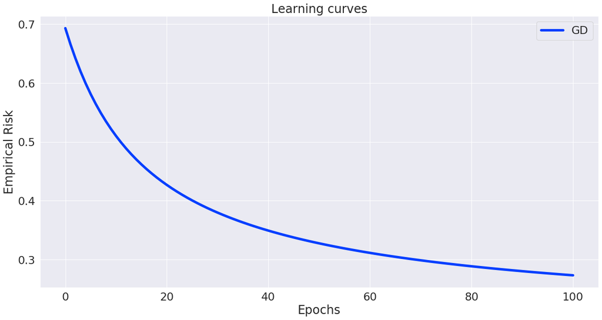

```python
from lib.linear_model import LogisticRegression
from lib.visuals import learning_curve

clf_gd = LogisticRegression(solver='gd', l2=0.01, max_iter=100)
clf_gd.fit(A_train, b_train)

learning_curve(GD=clf_gd)
```

The Standard Gradient Descent updates the parameters only after each epoch i.e. after calculating the gradients for all the observations it updates the parameters. This phenomenon may lead to the following caveats:

- Suppose we are working with a dataset which involves thousands of features and millions of data points (which is not uncommon in Machine Learning problems), then for each update to the parameter we would have thousand of derivatives and for each derivative, we would have millions of terms. That would be around a billion calculations for each step, which is computationally very very expensive. It will really slow down the process.
- For large datasets, the vectorization of data doesn’t fit into memory.
- For non-convex surfaces, it may only find the local minimums.

Now let see how different variations of gradient descent can address these challenges.

# SGD (Stochastic Gradient Descent)

In this section, we are interested in solving the following stochastic optimization problem :

$$min_{x \in R^d}(\mathbb{E}[f(x)]) \ \ \ (1)$$

To apply the SGD to the general form $(1)$ one needs to assume existence of unbiased gradient estimators. This is usually defined as follows:

$$\mathbb{E}[\nabla f_i (x)] = \nabla f(x)$$

The algorithm of this method is the following: At iteration k of the SGD algorithm, the following update is executed:

$$ \begin{cases} i \textrm{ chosen randomly in } \{1...n\}\\ x_{k+1} \leftarrow x_{k} - \gamma_k \nabla f_i(x_k) \\ \end{cases} $$

The idea of this method is that; rather than using the full gradient, we use just one training example which is super fast to compute.

Under the assumptions that, $f$ is $\mu$-strongly convex and $L$-smooth, let's check the convergence properties for this algorithm:

Let $x, y \in R^d$, we have: $$f(y) \leq f(x) + \langle y-x , \nabla f(x) \rangle + \frac{L}{2} \| x - y \|^2 $$

Let $ y = x_{k+1}$ and $x = x_k$, we have :

$$f(x_{k+1}) \leq f(x_{k}) - \gamma_k \langle \nabla f_{i}(x_k) , \nabla f(x_k) \rangle + \frac{L \gamma_k^2}{2}$$

We apply the function "Expectation" knowing $F_k$ which represents the history before $k$. we get:

\begin{equation} \begin{split} \mathbb{E}[f(x_{k+1})] & \leq f(x_{k}) - \gamma_k \langle \underbrace{\mathbb{E}[\nabla f_{i}(x_k)]}_{= \nabla f(x_k)} , \nabla f(x_k) \rangle + \frac{L \gamma_k^2}{2} \mathbb{E}[\| \nabla f_{i}(x_k) \|^2] \\ & \leq f(x_{k}) - (\gamma_k - \frac{L \gamma_k^2}{2}) \| \nabla f(x_k) \|^2 + \frac{L \gamma_k^2}{2} \underbrace{(\mathbb{E}[\| \nabla f_{i}(x_k) \|^2] - \underbrace{\| \nabla f(x_k) \|^2}_{= \|\mathbb{E}[\nabla f_{i}(x_k) \|^2} )}_{= Var(\nabla f_{i}(x_k))} \end{split} \end{equation}

With the assumption that we have a finite variance, i.e. $\exists \ \sigma > 0$ s.t. $Var(\nabla f_{i}(x_k)) \leq \sigma^2$, and by and summing over $k = 0, \ ..., \ T$ , we get that:

$$\mathbb{E}[f(x_{T+1})] + \sum_{k=0}^{T} \frac{\gamma_k (2-\gamma_k L)}{2} \mathbb{E} [ \| \nabla f(x_k) \|^2 ]\leq f(x_0) + \sum_{k=0}^{T} \frac{L \gamma_k^2 \sigma^2}{2} $$

From here, and according to what was proposed by Robbins and Monro,1951 for the classical SGD; A sufficient conditions for almost surely convergence is that:

$$\boxed{\sum_{k=0}^{\infty} \gamma_k = \infty \ , \ \sum_{k=0}^{\infty} \gamma_k^2 < \infty} $$

For example, we can take: $\boxed{\gamma_k = \frac{1}{k}}$

Furthermore, we have the following theorem: Let $f_i$ be $L$-smooth, $\sum_{k=0}^{\infty} \gamma_k = \infty$ and $\sum_{k=0}^{\infty} \gamma_k^2 < \infty$. We have:

$$\mathbb{E}[\| \nabla f(x_k) \|^2] \longrightarrow 0 \ \text{if f is convex} $$

Also, according to the work that has been showed in this article "SGD and Hogwild! Convergence Without the Bounded Gradients Assumption", we may get a better performance, if we take in addition to the last conditions, another one which is : $0 < \gamma_k \leq \frac{1}{2 L}$. Then, the following holds: $\| x_k - x^* \|^2 \longrightarrow 0$, where $x^* = argmin_{x \in R^d} f(x)$.

Finally, according to the same article, the following result establishes a sublinear convergence rate of the SGD:

Let $f$ be $\mu$-strongly convex and $L$-smooth. Let $E = \frac{2 \alpha L}{\mu}$ with $\alpha = 2$. Let's consider the SGD algorithm with a stepsize sequence such that $\gamma_t = \frac{\alpha}{\mu (t+E)} \leq \gamma_0 = \frac{1}{2 L}$. The expectation $\mathbb{E}[\| x_t - x^*\|^2]$ is at most: $\frac{4 \alpha^2 N}{\mu^2 (t-T+E)}$

For $t \geq T = \frac{4 L}{\mu}max [ \frac{L \mu}{N}\| x_0 - x^*\|^2,1 ] - \frac{4 L}{\mu}$ and $N = 2 \mathbb{E}[\| \nabla f(x^*)\|^2] $

**Question:**

- What stepsize $\gamma_k$ ensures the convergence of this algorithm and under what assumptions?
- Complete **TODO (5)**
- Add your code to **\lib\solvers.py**.

```python
def SGD(x0, grad, prox, max_iter, n, L, mu):
    x = x0
    x_tab = np.copy(x)

    for k in range(max_iter):
        stepsize = 1 / (k + 1)
        i = np.random.randint(n)
        y = grad(x, i)
        x = x - stepsize * y
        # If l1 = 0 then the prox is the identity, i.e. prox(x) = x
        x = prox(x, stepsize)

        if k != 0 and k % n == 0:  # each completed epoch
            x_tab = np.vstack((x_tab, x))

    return x, x_tab
```

**Question:** Run the code below to test your code.

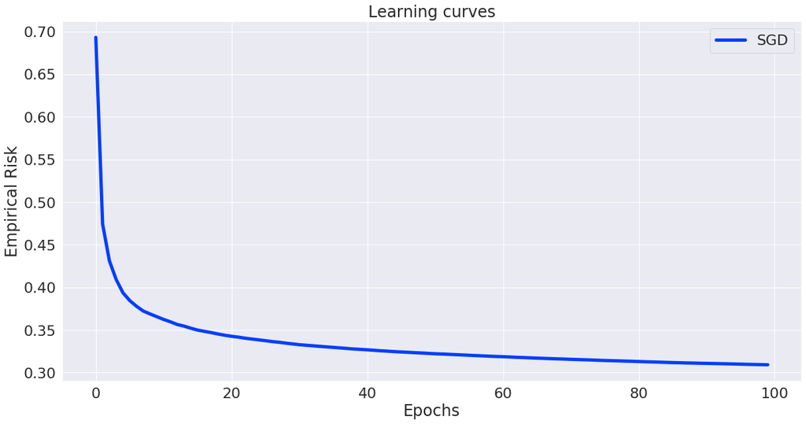

```python
clf_sgd = LogisticRegression(solver='sgd', l2=0.01, max_iter=100*len(b_train))
clf_sgd.fit(A_train, b_train)

learning_curve(SGD=clf_sgd)
```

The advantage of the Stochastic gradient is that each step only relies on a single gradient $\nabla f_i$, and thus the computational cost is $\frac{1}{n}$ that of the standard gradient descent. However, a disadvantage of the method is that the randomness introduces variance (this is caused by the fact that $\nabla f_i (x_k)$ is equals to $\nabla f(x_k)$ in expectation, and each $\nabla f_i (x_k)$ is different). This means that if $\nabla f_i (x_k)$ is large then we have a relatively large variance which slows down the convergence.

Also, due to the variance of random sampling, we generally need to choose $\eta_t = O(\frac{1}{t})$ and obtain a slower sub linear convergence rate of $O(\frac{1}{t})$. This is equivalent to say that we have a trade-off of fast computation per iteration and slow convergence for stochastic gradient descent versus slow computation per iteration and fast convergence for gradient descent.

In order to improve the SGD, one has to design some methods in order to reduce the variance, which allows us to use a large learning rate $\eta_t$.

# SAGA (Stochastic Average Gradient "Amélioré")

SAGA starts by computing a single batch gradient, then at iteration k, the following update is executed:

$$ \begin{cases} i \textrm{ chosen randomly in } \{1...n\}\\ x_{k+1} \leftarrow x_{k} - \gamma_k\big(\nabla f_i(x_k) - \alpha_i + \bar{\alpha}\big) \\ \alpha_i \leftarrow \nabla f_i(x) \end{cases} $$

where $(\alpha_j)_{j=1}^n$ are gradients evaluated at previous iterates and $\bar{\alpha}=\frac{1}{n}\sum^n_{j=1}\alpha_j$.

**Question:**

- What stepsize $\gamma_k$ ensures the convergence of this algorithm and under what assumptions?
- Complete **TODO (6)**
- Add your code to **\lib\solvers.py**.

### SAGA step convergence proof

In this part we will demonstrate the step needed to ensure convergence for the SAGA algorithm, presented in the original paper : "SAGA, a fast incremental Gradient method with support for non-strongly convex composites objectives"

It is different from the one we used since at each step, it applies a proximal operator.

- choose i at random uniformly
- compute $w^{k+1}$ : $$w^{k+1} = x^k - \gamma (\nabla f_i (x_k) -\nabla f_i (x_{k-1}) + \frac{1}{n} \sum_{j=1}^n \nabla f_j (x_{k-1})) $$
- apply the proximal operator on $w^{k+1}$ : $$ x^{k+1} = prox_{\gamma}^h (w^{k+1})$$

the proximal operator is defined as :

$$ prox_{\gamma}^h (w^{k+1}) = argmin_{x \in R^d} {h(x) + \frac{1}{2} ||x-w^{k+1}||^2} $$

To initialise the algorithm, we can perform a first step from $x_0$ to $x_1$ using a simple gradient descent, because at step 0, $x^{k-1}$ doesn't exist.

We aim to show that we achieve a convergence in the strongly convex case if $$\gamma = \frac{1}{2(\mu n +L)}$$

with L the Lipshitz constant , $\mu$ the strong convexity constant, and n ?

We present 3 Lemma used in the proof :

#### Lemma 1

with $f(x) = \frac{1}{n} \sum_{i=1}^n f_i(x)$, we suppose each $f_i$ to be $\mu-$strongly convex and to have lipschitz continuous gradient of constant L. for every $x^*$ and $x$ we then have :

\begin{align*} & <\nabla f(x), x^* -x> \leq \frac{L-\mu}{L} |f(x^*)-f(x)| \\ & - \frac{mu}{2} ||x^* - x||^2 - \frac{1}{2Ln} \sum_i ||\nabla f_i(x^*) - \nabla f_i(x) ||^2 - \frac{\mu}{L} < \nabla f(x^*),x-x^*> \\ \end{align*}

#### Lemma 2

For all x and $x^*$ we have :

$$\frac{1}{n} \sum_i||\nabla f_i(x)- \nabla f_i(x^*) ||^2 \leq 2L [\frac{1}{n} \sum_i f_i(x)- f(x^*) - \frac{1}{n} \sum_i < \nabla f_i(x^*),x-x^*>]$$

#### Lemma 3

with $x^{k-1}$, $x^k$, $x^*$ , $\beta>0$ and $w^{k+1}$, defined in the algorithm above, we have :

\begin{align*} & E ||w^{k+1} - x^k - \gamma \nabla f(x^*)||^2 \leq \gamma^2 (1+\beta^{-1}) E || \nabla f_i(x_{k-1}) - \nabla f_i(x^*)||^2 \\ & + \gamma^2 (1+\beta) E || \nabla f_i (x^k) - \nabla f_i(x^*)||^2 - \gamma^2 \beta ||\nabla f(x^k) - \nabla f(x^*)||^2 \end{align*}

#### Lemma 4

we suppose f $\mu$-strongly convex, then :

$$-||\nabla f(x^k) - \nabla f(x^*)||^2 \leq -2 \mu [f(x^k)-f(x^*) - <\nabla f(x^*),x^k-x^*>]$$

#### convergence of SAGA theorem

We consider $x^*$ the optimal solution, and we define the Lyapunov function T as :

$$T^k = T(x^k,x^{k-1}) = \frac{1}{n} \sum_j f_j(x^{k-1}) - f(x^*) - \frac{1}{n} \sum_j <\nabla f_j(x^*), x^{k-1}-x^*> +c ||x^k-x^* ||^2$$

with $\gamma = \frac{1}{2 \mu n +L}$, $c= \frac{1}{2\gamma(1-\gamma \mu)n}$ and $\kappa = \frac{1}{\gamma \mu}$, we have the following conditional expectation on $T^k$ bound between steps of the SAGA algorithm :

$$ E[T^{k+1}] \leq (1-\frac{1}{\kappa}) T^k $$

Proof :

let's compute independently bounds for the three linear terms in the conditional expectation $E[T^{k+1}]$ :

$$E[ \frac{1}{n} \sum_j f_j(x^{k})] = \frac{1}{n} f(x^k) + (1-\frac{1}{n}) \frac{1}{n} \sum_j f_j(x^{k-1})$$

$$E[- \frac{1}{n} \sum_j <\nabla f_j(x^*), x^{k}-x^*>] = - \frac{1}{n} <\nabla f(x^*), x^k-x^*> - (1-\frac{1}{n})\frac{1}{n} \sum_j <\nabla f_j(x^*), x^{k-1}-x^*>$$

for the last term we apply the non-expansiveness of the proximal operator :

\begin{align*} c ||x^{k+1}-x^*||^2 & = c || prox_{\gamma} (w^{k+1}) - prox_{\gamma} (x^* - \gamma \nabla f(x^*)) ||^2 \\ & \leq c ||w^{k+1} - x^* + \gamma \nabla f(x^*)||^2 \end{align*}

Expanding the quadratic and applying $E[w^{k+1}] = x^k - \gamma \nabla f(x^k)$ we have :

\begin{align*} & c E||w^{k+1} - x^* + \gamma \nabla f(x^*)||^2 = c E || x^k - x^* + w^{k+1} -x^k +\gamma \nabla f(x^*)||^2 \\ & = c ||x^k - x^*||^2 -2 c \gamma <\nabla f(x^k) - \nabla f(x^*), x^k-x^*> + c E || w^{k+1} - x^k + \gamma \nabla f(x^*)||^2 \\ & \text{Using Lemma 3, we have :} \\ & \leq c ||x^k - x^*||^2 -2 c \gamma <\nabla f(x^k), x^k-x^*> + 2 c \gamma <\nabla f(x^*), x^k-x^*> - c \gamma^2 \beta || \nabla f(x^k) - \nabla f(x^*)||^2 \\ & + (1+\beta^{-1})c \gamma^2 E||\nabla f_i(x^{k-1})- \nabla f_i(x^*)||^2 + (1+ \beta) c \gamma^2 E|| \nabla f_i(x^k)- \nabla f(x^*)||^2 \end{align*}

now we bound $-2 c \gamma <\nabla f(x^k),x^k-x^*>$ using Lemma 1 and we use Lemma 2 to bound $E||\nabla f(x^{k-1}) - \nabla f(x^*)||^2$ :

\begin{align*} & c E||x^{k+1} - x^*||^2 \leq (c-c \gamma \mu) ||x^k-x^*||^2 +((1+\beta)c \gamma^2 - \frac{c \gamma}{L}) E||\nabla f_i(x^k) - \nabla f_i(x^*)||^2 \\ & - \frac{2 c \gamma (L-\mu)}{L} [f(x^k)-f(x^*)-<\nabla f(x^*),x^k-x^*>] - c \gamma^2 \beta || \nabla f(x^k) - \nabla f(x^*)||^2 \\ & + 2 (1+ \beta^{-1}) c \gamma^2 L [\frac{1}{n} \sum_j f_j(x^{k-1}) - f(x^*) - \frac{1}{n} \sum_j <\nabla f_j(x^*), x^{k-1}-x^*>] \\ \end{align*}

We combine all the bounds now, and using Lemma 4 we can write, for any $\kappa$ for now :

\begin{align*} & E[T^{k+1}]-T^k \leq -\frac{1}{\kappa} T^k +(\frac{1}{n} - \frac{2c \gamma (L- \mu )}{L} - 2 c \gamma^2 \mu \beta)[f(x^k)-f(x^*) - <\nabla f(x^*),x^k-x^*>] \\ & + (\frac{1}{\kappa} +2(1+ \beta^{-1}) c \gamma^2 L - \frac{1}{n}) [\frac{1}{n} \sum_j f_j(x^{k-1}) - f(x^*) - \frac{1}{n} \sum_j <\nabla f_j(x^*), x^{k-1}-x^*>] \\ & + (\frac{1}{\kappa} - \gamma \mu) c ||x^k-x^*||^2 + ((1+\beta) \gamma - \frac{1}{L}) c \gamma E||\nabla f_i(x^k)- \nabla f_i(x^*)||^2 \end{align*}

now if we pose $\boxed{\gamma = \frac{1}{2(\mu n+L)}}$, $\boxed{c = \frac{1}{2 \gamma (1-\gamma \mu ) n }}$, $\boxed{\kappa = \frac{1}{\gamma \mu}}$ and $\boxed{\beta= \frac{2 \mu n +L}{L}}$ then each quantity in the square bracket is non-positive.

We can then use the fact that $c ||x^k-x^*||^2 \leq T^k$ and by using the constant and chaining the expectation we obtain our result :

$$\boxed{E[||x^k - x^*||^2] \leq (1- \frac{\mu}{2(\mu n +L)})^k [||x^0-x^*||^2 + \frac{n}{\mu n +L} [f(x^0)-<\nabla f(x^*),x^0-x^*> - f(x^*)]]}$$

with E here being the conditional expectation over all choice of i up to step k.

```python
def SAGA(x0, grad, prox, max_iter, n, L, mu):
    x = x0
    x_tab = np.copy(x0)
    stepsize = 1 / (2 * (mu * n + L))
    grads = np.zeros((n, len(x0)))

    for k in range(max_iter):
        i = np.random.randint(n)
        new_grad = grad(x, i)
        x = x - stepsize * (new_grad - grads[i] + np.mean(grads, axis=0))
        # If l1 = 0 then the prox is the identity, i.e. prox(x) = x
        x = prox(x, stepsize)
        grads[i] = new_grad

        if k != 0 and k % n == 0:  # each completed epoch
            x_tab = np.vstack((x_tab, x))

    return x, x_tab
```

**Question:** Run the code below to test your code.

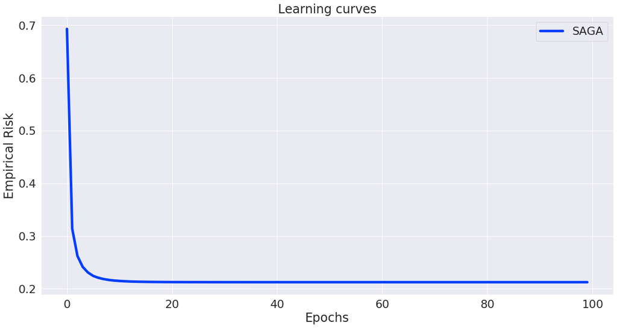

```python
clf_saga = LogisticRegression(solver='saga', l2=0.01, max_iter=100*len(b_train))
clf_saga.fit(A_train, b_train)

learning_curve(SAGA=clf_saga)
```

# SVRG (Stochastic Variance Reduced Gradient)

At iteration k of the SVRG algorithm, we perform the following:

$$ \begin{cases} \textrm{Compute the batch gradient } \nabla f(x_k)\\ \textrm{Initialise }y_0 = x_k\\ \textrm{for m in 0...M-1: } \begin{cases} i \textrm{ chosen randomly in } \{1...n\} \\ y_{m+1} \leftarrow y_{m} - \gamma_k\big(\nabla f_i(y_m) - \nabla f_i(x_k) + \nabla f(x_k)) \end{cases}\\ \text{Option 1}: x_{k+1} \leftarrow y_{M} \\ \text{Option 2}: x_{k+1} \leftarrow y_{t} \ \text{for randomly chosen t} \in \{0,...,M-1\} \end{cases} $$

In a practical implementation, we are going to take Option $1$, but in our analysis we are going to take Option $2$.

We will choose $M$ to be of the same order of $n$ but slightly larger (for example we will take $M=2 \times n$)

I recall that $f$ is strongly convex, $f_i$ is convex and $L$-smooth.

We have the following theorem:

- *$\underline{Theorem:}$*

Let's consider the SVRG with option $2$. Under the assumption that $f_i$ is convex, smooth and that $f$ is $\mu$-strongly convex.

Let $x^* = argmin_{x} f(x)$. Assume that $M$ is sufficiently large so that:

$$\alpha = \frac{1}{\mu M \gamma(1-2 L \gamma)} + \frac{2 L \gamma}{1-2L \gamma} < 1$$

Then we have geometric convergence for SVRG:

$$\mathbb{E} P (x_{k+1}) \leq \mathbb{E} P (x^*) + \alpha^k [P(x_1) - P(x^*)] $$

- *$\underline{Proof:}$*

Given any i, let: $g_i (x) = f_i (x) - f_i (x^*) - \langle \nabla f_i (x^*), x - x^* \rangle$ We have: $\nabla g_i(x) = \nabla f_i (x) - \nabla f_i (x^*) $, so $\nabla g_i (x^*) = 0$ which means that: $x^*$ is a minimiser of $g_i$. Therefore: $0=g_i (x^*) \leq min_{\gamma} [g_i (x) - \gamma \nabla f_i (x))]$ and using the fact that $f_i$ is $\mu$-strongly convex and $L$-smooth, we get that (and by taking $\gamma = \frac{1}{L}$): $0=g_i (x^*) \leq f_i (x) - \frac{1}{2 L} \| \nabla f_i (x) \|^2 $

That is: $$ \| \nabla f_i (x) - \nabla f_i (x^*) \|^2 \leq 2 L [f_i (x) - f_i (x^*) - \langle \nabla f_i (x^*), x - x^* \rangle ]$$

And by summing the above inequality over $i = 1, ..., n$, and using the fact that: $\nabla f (w^*) = 0$, we obtain:

$$\frac{1}{n} \sum_{i=1}^n \| \nabla f_i (x) - \nabla f_i (x^*) \|^2 \leq 2 L [f(x) - f(x^*)]$$

We can now proceed to prove the theorem. Let: $v_m = (\nabla f_{i_m}(y_m) - \nabla f_{i_m}(x_k) + \nabla f(x_k))$. We can take the expectation with respect to $i_m$, and obtain after some basic calculation that: $$\mathbb{E} \| v_m \|^2 \leq 4 L [ f(y_m) - f(x^*) + f(x_k) -f(x^*) ] $$

Now, by noticing that conditioned on $y_m$, we have: $\mathbb{E} v_m = \nabla f(y_m)$, and this leads to:

$$\mathbb{E} \| y_m - x^* \|^2 = \| y_{m-1} - x^* \|^2 - 2 \gamma \langle y_{m-1} - x^*, \mathbb{E} v_m \rangle + \gamma^2 \mathbb{E} \| v_m \|^2$$ So, $$\mathbb{E} \| y_m - x^* \|^2 \leq \| y_{m-1} - x^* \|^2 - 2 \gamma \langle y_{m-1} - x^*, \nabla f (y_m) \rangle + 4 L \gamma^2 [ f(y_m) - f(x^*)+ f(x_k) - f(x^*)]$$

$$\mathbb{E} \| y_m - x^* \|^2 \leq \| y_{m-1} - x^* \|^2 - 2 \gamma [f(y_m) -f(x^*)] + 4 L \gamma^2 [ f(y_m) - f(x^*)+ f(x_k) - f(x^*)] $$

$$ = \| y_{m-1} - x^* \|^2 - 2 \gamma (1 - 2 L \gamma) [f(y_m) - f(w^*)] + 4 L \gamma^2 [f(x_k) - f(x^*)] $$

The first inequality uses the previously obtained for $\mathbb{E} \| v_m \|^2$, and the second inequality convexity of $f$, which implies that: $- \langle y_m - x^*, \nabla f(y_m) \rangle \leq f(x^*) - f(y_m)$

We consider a fixed stage $k$, and $x_{k+1}$ is selected after all of the updates have completed. Bu summing the previous inequality over $t = 1,…,m$ taking expectation with all the history, and using option $2$, we obtain:

$$\mathbb{E} \| y_{M} - x^* \|^2 + 2 \gamma (1-2L\gamma)m \mathbb{E} [f(x_{k+1} - f(x^*)] \leq \mathbb{E} \| y_{0} - x^* \|^2 + 4 L m \gamma^2 \mathbb{E} [f(x_{k} - f(x^*)] $$

$$ = \mathbb{E} \| x_k - x^* \|^2 + 4 L m \gamma^2 \mathbb{E} [f(x_{k} - f(x^*)] $$

$$\leq \frac{2}{\mu} \mathbb{E} [f(x_{k} - f(x^*)] + 4 L m \gamma^2 \mathbb{E} [f(x_{k} - f(x^*)]$$

$$ = 2 (\frac{1}{\gamma} + 2 L m \gamma^2 \mathbb{E} [f(x_{k} - f(x^*)])$$

The second inequality uses the strong convexity property. We thus obtain:

$$ \mathbb{E}[f(x_{k+1}) - f(x^*)] \leq [\frac{1}{\mu \gamma (1-2L \gamma)M} + \frac{2 L \gamma}{1 - 2 L \gamma}] \mathbb{E} [f(x_{k} - f(x^*)]$$

This implies that:

$$\boxed{\mathbb{E}[f(x_{k+1}) - f(x^*)] \leq \alpha^k \mathbb{E} [ f(x_1) -f(x^*)]} $$

In our procedure, we may take: $\boxed{\gamma = \frac{0.1}{L}}$ and $\boxed{M = O(n)}$ in order to obtain a convergence rate of $\alpha = \frac{1}{2}$.

**Question:**

- What stepsize $\gamma_k$ ensures the convergence of this algorithm and under what assumptions?
- Complete **TODO (7)**
- Add your code to **\lib\solvers.py**.

```python
def SVRG(x0, grad, prox, max_iter, n, L, mu):
    M = 2 * n
    x = x0
    x_tab = np.copy(x0)

    stepsize = 0.1 / L

    for k in range(max_iter):
        batch_grad = grad(x)
        y = np.copy(x)
        for m in range(M):
            i = np.random.randint(n)
            y = y - stepsize * (grad(y, i) - grad(x, i) + batch_grad)
            # If l1 = 0 then the prox is the identity, i.e. prox(y) = y
            y = prox(y, stepsize)
        x = y

        for i in range(5):
            x_tab = np.vstack((x_tab, x))

    return x, x_tab
```

**Question:** Run the code below to test your code.

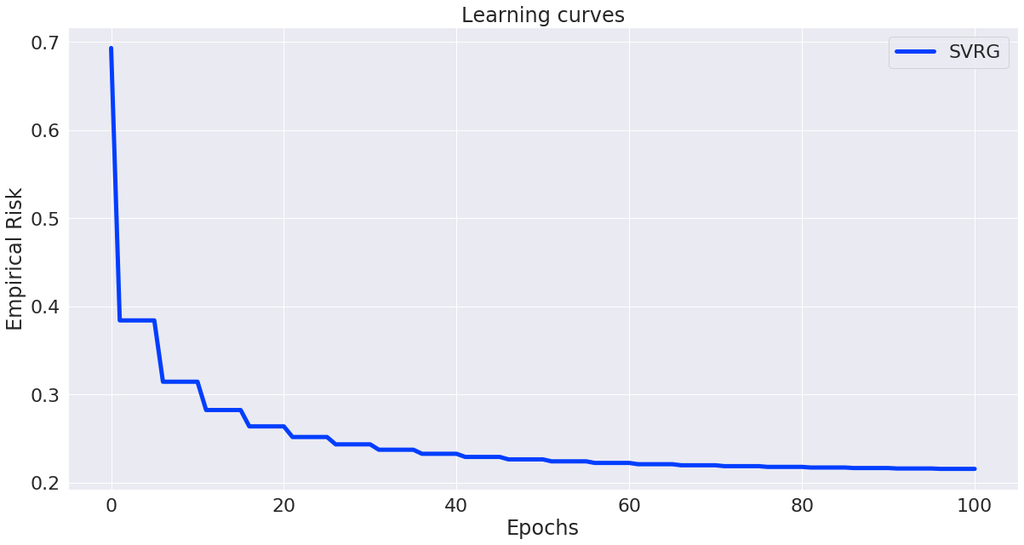

```python
clf_svrg = LogisticRegression(solver='svrg', l2=0.01, max_iter=20)
clf_svrg.fit(A_train, b_train)
learning_curve(SVRG=clf_svrg)
```

# Comparison

**Question:** Run the code below to compare all the methods you've implemented.

```python
epochs = 50
n = len(b_train)

clf_gd   = LogisticRegression(solver='gd', l2=0.01, max_iter=epochs)
clf_sgd  = LogisticRegression(solver='sgd', l2=0.01, max_iter=epochs*n)
clf_saga = LogisticRegression(solver='saga', l2=0.01, max_iter=epochs*n)
clf_svrg = LogisticRegression(solver='svrg', l2=0.01, max_iter=int(epochs/5))

clf_gd.fit(A_train, b_train)
clf_sgd.fit(A_train, b_train)
clf_saga.fit(A_train, b_train)
clf_svrg.fit(A_train, b_train)
```

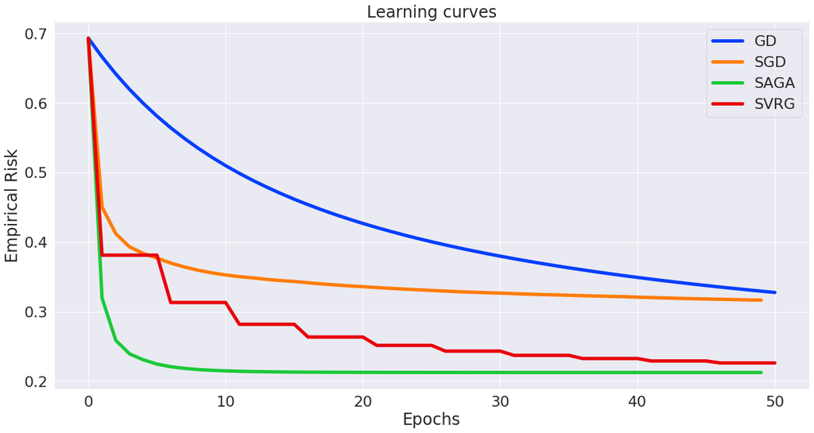

```
gd:	Accuracy on training set: 90.9%
	Accuracy on testing set:  87.9%
sgd:	Accuracy on training set: 87.2%
	Accuracy on testing set:  88.9%
saga:	Accuracy on training set: 95.6%
	Accuracy on testing set:  90.9%
svrg:	Accuracy on training set: 92.9%
	Accuracy on testing set:  91.9%
```

```python
learning_curve(GD=clf_gd, SGD=clf_sgd, SAGA=clf_saga, SVRG=clf_svrg)

for clf, name in zip([clf_gd, clf_sgd, clf_saga, clf_svrg], ['gd', 'sgd', 'saga', 'svrg']):
    print(name + ':' \
          + "\tAccuracy on training set: {0:0.1f}%".format(100*clf.score(A_train, b_train)))
    print("\tAccuracy on testing set:  {0:0.1f}%".format(100*clf.score(A_test, b_test)))
```

# IV. Regularization

**Question:**

- Rewrite the empirical risk minimization objective with both $L_1$ and $L_2$ regularization (with coefficients $l_1$ and $l_2$).
- Is this objective $\mu$-strongly convex, $L$-smooth, differentiable?
- Complete the **TODO (8)** to account for the new term in the objective.
- Add your code to **lib/linear_model.py**.

> **Answer:**

Here we minimize the empirical risk $g$ of the $L_2$+$L_1$-regularized logistic regression model, on the dataset $(A_{\textrm{train}},b_{\textrm{train}})$:

$$ \begin{aligned} \textrm{min}_{x\in \mathbb{R}^d} \ g(x) \ &= \ \textrm{min}_{x\in \mathbb{R}^d} \ \frac{1}{n_{\textrm{train}}} \sum_{i=1}^{n_{\textrm{train}}} g_i(x) \\ &= \ \textrm{min}_{x\in \mathbb{R}^d}\frac{1}{n_{\textrm{train}}} \sum_{i=1}^{n_{\textrm{train}}} \textrm{LogisticLoss}(b_i, \left\langle a_{i}, x\right\rangle ) + \frac{l_2}{2}\|x\|^{2}_2 + l_1 \|x\|_1, \end{aligned} $$

This new regularized risk $g$ is not differentiable in $0$ because of $\|x\|_1$.

And it is not $L$-smooth, because by definition of smoothness it must be differentiable, and $\nabla$ is $L$ lipschitz.

Also, the logistic loss is convex, and a norm is convex (we use the triangular inequality). So $g$ is convex.

Finally, the logistic loss, $x \longmapsto l_1 \|x\|_1$ are convex so there are $0$-strongly convex. And $x \longmapsto \frac{l2}{2}\|x\|_2^2$ is $l_2$-strongly convex. We conclude then, that g is $\mu$-strongly convex with $\mu \geq l_2$

```
self._empirical_risk = lambda x: sum(self._logistic_loss(A, b, x))/n \
                                 + self.l2/2.0 * pow(np.linalg.norm(x,2),2) \
                                 + self.l1 * np.linalg.norm(x,1)
```

The minimization algorithms we've implemented have a slow rate of convergence for this new objective function. We will therefore use *proximal* variations of these algorithms.

**Question:** Using the $\textrm{prox}_{l_1 \|\cdot\|_1}$ operator, write down the $k^{th}$ step of proximal GD, proximal SGD, proximal SAGA, and proximal SVRG.

> **Answer:**
- *$\underline{Proximal \ GD}$:*

The $k^{th}$ step of the proximal GD is : $$ x_{k+1} \leftarrow \mathbf{prox}_{\gamma l_1 \|\cdot\|_1}\left( x_k - \gamma \nabla f(x_k) \right) $$ Where $\gamma$ is a stepsize to choose.

- *$\underline{Proximal \ SGD}$:*

The $k^{th}$ step of the proximal SGD is :

$$ \begin{cases} i \textrm{ chosen randomly in } \{1...n\}\\ x_{k+1} \leftarrow \mathbf{prox}_{\gamma_k l_1 \|\cdot\|_1} \left( x_{k} - \gamma_k \nabla f_{i}(x_{k}) \right) \\ \end{cases} $$ Where $\gamma_k$ is a step size vanishing like $\frac{1}{k}$ .

- *$\underline{Proximal \ SAGA}$:*

Like before the proximal SAGA starts by computing a single batch gradient, then at iteration $k$, the following update is executed:

$$ \begin{cases} i \textrm{ chosen randomly in } \{1...n\}\\ x_{k+1} \leftarrow \mathbf{prox}_{\gamma l_1 \|\cdot\|_1} \left(x_{k} - \gamma \big(\nabla f_i(x_k) - \alpha_i + \bar{\alpha}\big) \right) \\ \alpha_i \leftarrow \nabla f_i(x) \end{cases} $$

Where $\gamma$ is a stepsize to choose, $(\alpha_j)_{j=1}^n$ are gradients evaluated at previous iterates and $\bar{\alpha}=\frac{1}{n}\sum^n_{j=1}\alpha_j$.

- *$\underline{Proximal \ SVRG}$:*

At iteration $k$ of the Proximal SVRG algorithm, we perform the following:

$$ \begin{cases} \textrm{Compute the batch gradient } \nabla f(x_k)\\ \textrm{Initialise }y_0 = x_k\\ \textrm{for m in 0...M-1: } \begin{cases} i \textrm{ chosen randomly in } \{1...n\} \\ y_{m+1} \leftarrow \mathbf{prox}_{\gamma l_1 \|\cdot\|_1} \left( y_{m} - \gamma \big(\nabla f_i(y_m) - \nabla f_i(x_k) + \nabla f(x_k)\big) \right) \end{cases}\\ x_{k+1} \leftarrow y_{M} \end{cases} $$

Where $\gamma$ and $M$ are two constants to choose.

**Question:**

- Give a closed-form expression of $\textrm{prox}_{l_1 \|\cdot\|_1}$
- Complete **TODO (9)** (note that you can access the $l_1$ coefficient using **self.l1**).
- Add your code to **\lib\linear_model.py**.

> **Answer:**

The proximal operator $\textrm{prox}_{f} \ : \ R^n \longrightarrow R^n $ of a function $f$ is defined by: $$\forall v \in R^n \ \ \ \textrm{prox}_{f}(v) \ = \ argmin_{x \in R^n} \left( f(x) + \frac{1}{2}\| x - v \|_{2}^{2} \right)$$

We often use the proximal operator of the scaled function $\lambda f$, where $\lambda > 0$, which can be expressed as : $$\textrm{prox}_{\lambda f}(v) \ = \ argmin_{x \in R^n} \left( \lambda f(x) + \frac{1}{2}\| x - v \|_{2}^{2} \right)$$

We know that, if $f$ is fully separable, meaning that $f(x) = \sum_{i=1}^{n} f_{i}(x_{i})$, then:

$$(\textrm{prox}_{\lambda f}(v))_i = \textrm{prox}_{\lambda f_i}(v_i)$$

Thus, evaluating the proximal operator of a separable function reduces to evaluating the proximal operators for each of the separable parts, which can be done independently, because if we take $ (v_1,\ ... \ ,v_n) \in R^n$ we get:

\begin{equation} \begin{split} \textrm{prox}_{\lambda f}(v_1,\ ... \ ,v_n) & = argmin_{(x_1,\ ... \ ,x_n) \in R^n} \sum_{i=1}^{n} \left( \lambda f_i (x_i) + \frac{1}{2} (v_i - x_i)^2 \right) \\ & = \prod_{i=1}^{n} argmin_{x_i \in R} \left( \lambda f_i (x_i) + \frac{1}{2} (v_i - x_i)^2 \right) \\ & = \prod_{i=1}^{n} \textrm{prox}_{\lambda f_i}(v_i) \end{split} \end{equation}

Now, in one dimension, if we take $f(x) = l_1 \ |x \ |$, we know that:

$$\forall v \in R \ \ \ \textrm{prox}_{\lambda f}(v) = \textrm{prox}_{\lambda l_1 \ |x \ |}(v) = \begin{cases} v + \lambda l_1 \ \ \ \ if \ v \leq - \lambda l_1 \\ 0 \ \ \ \ \ \ \ if \ y \in [ - \lambda l_1 , \lambda l_1 ] \\ v - \lambda l_1 \ \ \ \ \ if \ v > \lambda l_1 \end{cases} $$

By generalizing to $R^n$ we get: $$ \forall v \in R^n \ \ \ \left( \textrm{prox}_{\lambda l_1 \|x \|_1}(v) \right)_i = \begin{cases} v_i + \lambda l_1 \ \ \ \ if \ v_i \leq - \lambda l_1 \\ 0 \ \ \ \ \ \ \ if \ y \in [ - \lambda l_1 , \lambda l_1 ] \\ v_i - \lambda l_1 \ \ \ \ \ if \ v_i > \lambda l_1 \end{cases} $$

```python
def prox(x, stepsize):
    output = np.empty(len(x))
    for i in range(len(output)):
        if x[i] >= stepsize * self.l1:
            output[i] = x[i] - stepsize * self.l1
        elif x[i] <= -stepsize * self.l1:
            output[i] = x[i] + stepsize * self.l1
        else:
            output[i] = 0
    return output
```

**Question:**

- Add **prox** to the attributes of the solvers (both in the call to **self.solver** in **/lib/linear_model.py** and in **/lib/solvers.py**) as follows:  
  solver(x0, grad, **prox**, self.max_iter, n, L, mu)
- Add a proximal step to all the algorithms in **/lib/solvers.py**.
- Paste one of these algorithms in the cell bellow.

```
def SVRG(x0, grad, prox, max_iter, n, L, mu):
    M = 2 * n
    x = x0
    x_tab = np.copy(x0)

    stepsize = 0.1 / L

    for k in range(max_iter):
        batch_grad = grad(x)
        y = np.copy(x)
        for m in range(M):
            i = np.random.randint(n)
            y = y - stepsize * (grad(y, i) - grad(x, i) + batch_grad)
        x = y
        x = prox(x, stepsize)

        for i in range(5):
            x_tab = np.vstack((x_tab, x))

    return x, x_tab
```

**Question:** If your proximal gradient descent is correctly implemented, the following cell will plot the support of the solution for various values of $l_1$.

- Interpret the plot and explain what can $L_1$ regularization be used for.

> **Answer:**

As the L1 constant regularisation gets bigger, we see that the number of null-coordinates of the final solution gets bigger as well.

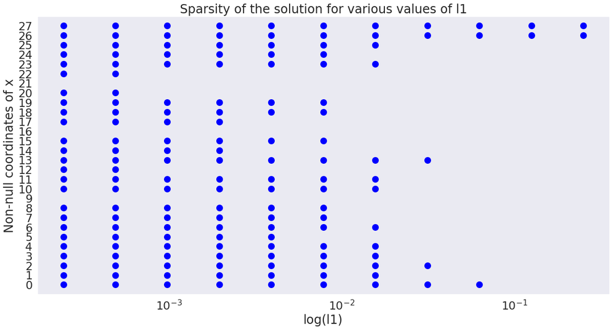

```python
from lib.visuals import l1_regularization_plot

clf = lambda l1: LogisticRegression(solver='gd', l1=l1, l2=0.1, max_iter=1000)

l1_regularization_plot(clf, A_train, b_train)
```

The l1-regularization adds a penalty that is just the sum of the absolute values of the coordinates of $x$. As such, it allows to make the coordinates vector sparse by setting to $0$ all the coordinates close to $0$. It can be seen as a kind of dimension-reduction by only setting to non-null coordinates that have a big importance on the result. This regularization is popular because it allows to simplify the problem by reducing its dimension, and so is a form of model selection.

**Question:** The following cell will plot the value of the coordinates of the solution for various values of $l_2$.

- Interpret the plot and explain what can $L_2$ regularization be used for.

> **Answer:**

The l2-regularization is giving much more penalty to the coordinates far from $0$ than to the coordinates close to $0$. It is useful because it is constraining the model to avoid overfitting on the dataset.

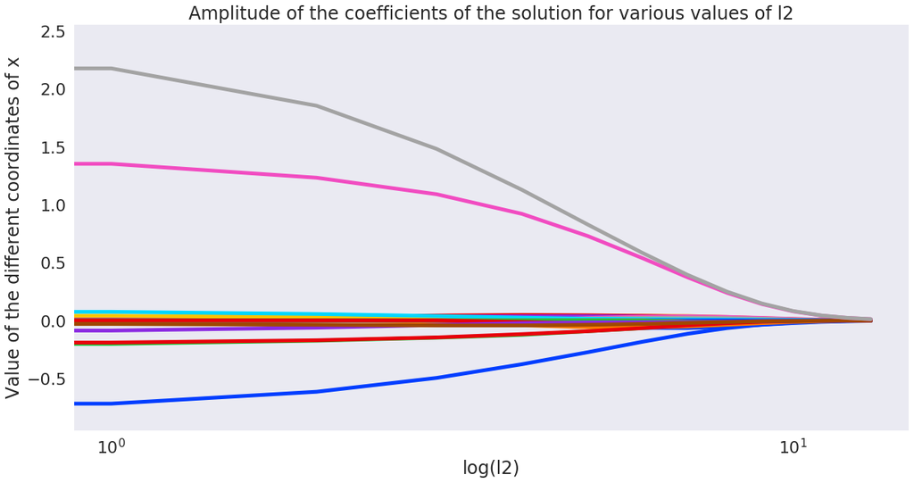

```python
from lib.visuals import l2_regularization_plot

clf = lambda l2: LogisticRegression(solver='gd', l1=0.01, l2=l2, max_iter=1000)

l2_regularization_plot(clf, A_train, b_train)
```

To summarize all what we said before, we can say that, we may add a $l_1$ and $l_2$ regularizer in order to do a model selection, i.e. to choose the features that most influence the output. Also, these regularizer may be used in order to avoid over-fitting.

Now another question arise, how to choose the best parameter/ parameters ($l_1$ and/or $l_2$) such that our model is much more stable? I am talking about stability because it’s an important notion in many field like biomedical one.

A state of the art measure, to measure the stability of an algorithm, is the one presented in this article http://www.jmlr.org/papers/volume18/17-514/17-514.pdf

In this article, they showed that sometimes it’s better to choose the parameters that lead to a slight loss in the accuracy but a large gain in stability.

# $\underline{\text{A Logistic Regression Problem:}}$

In this section, we are going to consider the [ionosphere](https://archive.ics.uci.edu/ml/machine-learning-databases/ionosphere/ionosphere.names) data set.

This data set, which we denote $\mathcal{D}$ is consisting of $m = 351$ examples; each example is consisting of a feature vector $a_i \in \mathbb{R}^d$, where $d = 34$.

The goal of this supervised learning problem, which is a binary classification problem, i.e. $\mathcal{O} = \{-1 , +1 \}$ is to construct a predictor for the observations when given feature vectors. A popular approch to do so, is to use linear models, which are based on finding a parameter $w$. The latter will help us find the hyperplane wich separates well the two classes.

In order to find the parameter $w$, we use the data we have, with a loss function $l$ in order to penalizes the error between the predicted class and the true class of each example. If we take the $i^{th}$ example $(a_i , b_i)$, the corresponding error function that we take is: $f_i(x) = \ell( h(\langle a_i , w \rangle) ; b_i )$, where $h$ is the prediction function.

We want to minimize the error over all the data, so our minimization problem can be reformulated as follows:

$$\min_{w \in \mathbb{R}^d} f(w) = \min_{w \in \mathbb{R}^d} \frac{1}{m} \sum_{i=1}^m f_i(w) = \frac{1}{m} \sum_{i=1}^m \ell( h(\langle a_i , w \rangle) ; b_i )$$

We take $l$ as the Logistic loss, so the last minimization problem is equivalent to:

$$\min_{w \in \mathbb{R}^d } f(w) := \frac{1}{m} \sum_{i=1}^m \log( 1+\exp(-b_i \langle a_i,w \rangle) ) + \frac{\lambda}{2} \|w\|_2^2$$

One of the reasons why we add the last term is to avoid overfitting.

Once we find the solution of the last minimization problem, which we denote it by $w^*$, we use a bayesian approach in order to predict the class of a new example.

Indeed, if $z$ is a new example. We compute: $\mathbb{P}[z \in \text{ class } +1]$. Thus, one can decide that $z$ belongs to the class $+1$ if this probability is close to one, and to the class $-1$ otherwise.

Now, let's start programming :) :

First, we start by preprocessing the data set we found and by initializing our variables.

```python
import numpy as np
import csv
from sklearn import preprocessing

file = open('ionosphere.data')

d = 34  # Our features are of dimension 34
n = d+1 # Variable size + intercept (The class label of each example)

m = 351 # Number of examples

lam = 0.001 # The regularization parameter

A = np.zeros((m,d)) # A will be our data set
b = np.zeros(m)     # b if a vector that will contains the labels of examples

reader = csv.reader(file, delimiter=',')

# we affect each element to a given class based on the last element of each line of the file 'reader'
i = 0
for row in reader:
    A[i] = np.array(row[:d])
    if row[d] == 'b':
        b[i] = -1.0
    else:
        b[i] =  1.0
    i+=1

# We process the matrix A using the library 'sklearn'
scaler = preprocessing.StandardScaler().fit(A)
A = scaler.transform(A)

# Adding an intercept
A_inter = np.ones((m,n))
A_inter[:,:-1] = A
A = A_inter

# We define 'L' as before
L = 0.25*max(np.linalg.norm(A,2,axis=1))**2 + lam
```

Now we define our function $f$ and our oracle:

```python
def f(x):
    l = 0.0
    for i in range(A.shape[0]):
        if b[i] > 0 :
            l += np.log( 1 + np.exp(-np.dot( A[i] , x ) ) )
        else:
            l += np.log( 1 + np.exp(np.dot( A[i] , x ) ) )
    return l/m + lam/2.0*np.dot(x,x)

def f_grad(x):
    g = np.zeros(n)
    for i in range(A.shape[0]):
        if b[i] > 0:
            g += -A[i]/( 1 + np.exp(np.dot( A[i] , x ) ) )
        else:
            g += A[i]/( 1 + np.exp(-np.dot( A[i] , x ) ) )
    return g/m + lam*x
```

In order to predict the class of a new example, we define the following functions:

```python
def prediction(w,verbose=False):
    predictions = np.zeros(A.shape[0])
    perf = 0
    for i in range(A.shape[0]):
        p = 1.0/( 1 + np.exp(-np.dot( A[i] , w ) ) )
        if p>0.5:
            predictions[i] = 1.0
            if b[i]>0:
                correct = "True"
                perf += 1
            else:
                correct = "False"
            if verbose:
                print("True class: {:d} \t-- Predicted: {} \t(confidence: {:.1f}%)\t{}".format(int(b[i]),1,(p-0.5)*200,correct))
        else:
            predictions[i] = -1.0
            if b[i]<0:
                correct = "True"
                perf += 1
            else:
                correct = "False"
            if verbose:
                print("True class: {:d} \t-- Predicted: {} \t(confidence: {:.1f}%)\t{}".format(int(b[i]),-1,100-(0.5-p)*200,correct))
    return predictions,float(perf)/A.shape[0]
```

I am going to define the Gradient Descent algorithm, but without using the prox operator (Because everything is differentiable).

```python
def GD(x0, grad, prox, max_iter, n, L, mu):
    stepsize = 0.9 / L
    x = x0
    x_tab = np.copy(x)

    for k in range(max_iter):
        y = grad(x)
        x = x - stepsize * y
        x_tab = np.vstack((x_tab, x))

    return x, x_tab
```

Now it's time to apply our gradient descent algorithm to this data set.

To do so, we start by itializing our parameters, then we call the prediction function that we define just above.

```python
max_iter = 500   # The maximum number of iterations
x0 = np.zeros(n) # The initial point
mu = 0.05        # The parameter of the mu strong convexity

# Here we solve the minimization problem we have using the GD
x,x_tab = GD(x0, f_grad, prox, max_iter, n, L, mu)

pred,perf = prediction(x)
print("Gradient algorithm: \t{:.2f}%".format(perf*100))
```

```
Gradient algorithm: 	90.03%
```

We got a percentage of 90%, wich is quite good. But there is still work to do

In order to do better, we are going to try to use a second order algorithm, which is 'Newton Algorithm'.

The principle of this algorithm is the following:

In order to minimize a twice differentiable function $f:\mathbb{R}^n \to \mathbb{R}$, given:

- the function to minimize f
- a 2nd order oracle f_grad_hessian
- an initialization point x0
- a maximal number of iterations ITE_MAX

We do the following updates for the sequence $x_k$:

$$ x_{k+1} = x_k - [\nabla^2 f(x_k) ]^{-1} \nabla f(x_k) $$

As we see, this algorithm doesn't need to define a proper step size...

The algorithm for the second order oracle for the function $f$ defined above is the following:

```python
def f_grad_hessian(x):
    g = np.zeros(n)
    H = np.zeros((n,n))
    for i in range(A.shape[0]):
        if b[i] > 0:
            g += -A[i]/( 1 + np.exp(np.dot( A[i] , x ) ) )
            H +=  (np.exp(np.dot( A[i] , x ))/( 1 + np.exp(np.dot( A[i] , x ) ) )**2)*np.outer(A[i],A[i])
        else:
            g += A[i]/( 1 + np.exp(-np.dot( A[i] , x ) ) )
            H +=  (np.exp(-np.dot( A[i] , x ))/( 1 + np.exp(-np.dot( A[i] , x ) ) )**2)*np.outer(A[i],A[i])
    g =  g/m + lam*x
    H = H/m + lam*np.eye(n)
    return g,H
```

Then the Newton algorithm is:

```python
def newton_algorithm(f,f_grad_hessian,x0,max_iter):
    x = np.copy(x0)
    g0,H0 = f_grad_hessian(x0)
    x_tab = np.copy(x)
    for k in range(max_iter):
        g,H = f_grad_hessian(x)
        x = x - np.linalg.solve(H,g)
        x_tab = np.vstack((x_tab,x))
    return x,x_tab
```

```python
# We take the same initial point as before, as well as the same number of iteration
x_newton,x_tab_newton = newton_algorithm(f,f_grad_hessian,x0,max_iter)


pred_newton,perf_newton = prediction(x_newton)
print("Newton Algorithm: \t{:.2f}%".format(perf_newton*100))
```

```
Newton Algorithm: 	94.02%
```

As we can see, we get a better rate than the case for the gradient descent algorithm.

The only problem that we remark, is that the newton method takes a lot of time than the first on.

Now let's pratice these methods on another data set.

## $\underline{\text{Test on Arcene dataset:}}$

https://archive.ics.uci.edu/ml/datasets/Arcene

The Arcene dataset contains mass-spectrometric data and labels for this data. The samples include patients with cancer (ovarian or prostate cancer), and healthy or control patients. +1 indicates the presence of a cancer and -1 the absence of it.

```python
import numpy as np
import csv
from sklearn import preprocessing

file_test_train = open('Arcenedata/arcene_train.data')
file_test_label = open('Arcenedata/arcene_train.labels')

d = 10000  # Our features are of dimension 34
n = d+1 # Variable size + intercept (The class label of each example)

m = 100 # Number of examples

lam = 0.001 # The regularization parameter

A = np.zeros((m,d)) # A will be our data set
b = np.zeros(m)     # b if a vector that will contains the labels of examples

reader = csv.reader(file_test_train, delimiter=' ')
reader_label = csv.reader(file_test_label, delimiter=' ')

# we affect each element to a given class based on the last element of each line of the file 'reader'
i = 0
for row in reader:
    A[i] = np.array(row[:d])
    i+=1

i=0
for row in reader_label:
    b[i]= np.array(row[:d])
    i+=1

# We process the matrix A using the library 'sklearn'
scaler = preprocessing.StandardScaler().fit(A)
A = scaler.transform(A)

# Adding an intercept
A_inter = np.ones((m,n))
A_inter[:,:-1] = A
A = A_inter

# We define 'L' as before
L = 0.25*max(np.linalg.norm(A,2,axis=1))**2 + lam
```

```python
def prediction(w,verbose=False):
    file_test_train = open('Arcenedata/arcene_valid.data')
    file_test_label = open('Arcenedata/arcene_valid.labels')

    Avalid = np.zeros((m,d)) # A will be our data set
    bvalid = np.zeros(m)     # b if a vector that will contains the labels of examples

    reader = csv.reader(file_test_train, delimiter=' ')
    reader_label = csv.reader(file_test_label, delimiter=' ')

    # we affect each element to a given class based on the last element of each line of the file 'reader'
    i = 0
    for row in reader:
        Avalid[i] = np.array(row[:d])
        i+=1

    i=0
    for row in reader_label:
        bvalid[i]= np.array(row[:d])
        i+=1

    # We process the matrix A using the library 'sklearn'
    scaler = preprocessing.StandardScaler().fit(Avalid)
    Avalid = scaler.transform(Avalid)

    # Adding an intercept
    A_intervalid = np.ones((m,n))
    A_intervalid[:,:-1] = Avalid
    Avalid = A_intervalid

    predictions = np.zeros(Avalid.shape[0])
    perf = 0
    for i in range(Avalid.shape[0]):
        p = 1.0/( 1 + np.exp(-np.dot( Avalid[i] , w ) ) )
        if p>0.5:
            predictions[i] = 1.0
            if bvalid[i]>0:
                correct = "True"
                perf += 1
            else:
                correct = "False"
            if verbose:
                print("True class: {:d} \t-- Predicted: {} \t(confidence: {:.1f}%)\t{}".format(int(b[i]),1,(p-0.5)*200,correct))
        else:
            predictions[i] = -1.0
            if bvalid[i]<0:
                correct = "True"
                perf += 1
            else:
                correct = "False"
            if verbose:
                print("True class: {:d} \t-- Predicted: {} \t(confidence: {:.1f}%)\t{}".format(int(b[i]),-1,100-(0.5-p)*200,correct))
    return predictions,float(perf)/Avalid.shape[0]
```

```python
max_iter = 500   # The maximum number of iterations
x0 = np.zeros(n) # The initial point
mu = 0.05        # The parameter of the mu strong convexity

# Here we solve the minimization problem we have using the GD
x,x_tab = GD(x0, f_grad, prox, max_iter, n, L, mu)

pred,perf = prediction(x)
print("Gradient algorithm: \t{:.2f}%".format(perf*100))
```

```
Gradient algorithm: 	80.00%
```

We get a rate of $80 \%$ which is not that good. So may do better by using a second order method like we did before, or just using SGD, SVRG or SAGA.

Finally, we conclude that this lab helped us to understand a lot of things in optimization, and to discover (for the first time) many algorithms that can be used to minimize a function.

One of the most difficulties that we encountered during this lab was to understand the proofs of the step size for the SRVG and the SAGA algorithms.

And the fact that we applied these algorithms to different datasets allowed us to better understand all of what we have done before.